# Seçim Kampanyası Coğrafi Verimlilik Kılavuzu / 2023

## Giriş

2023 milletvekili genel seçimlerinde Ankara 2. Bölge parlamentoya on bir milletvekili gönderecek. 2018’de gerçekleşen seçimlerde AK Parti altı, CHP ise iki milletvekili elde etmişti. 2023 seçimlerine giderken Türkiye genelinde olduğu gibi Ankara’da da siyasi aritmetiğin değiştiği aşikardır. Raporda, 2015 Kasım, 2018 Cumhurbaşkanlığı ve milletvekili seçimlerinin sonuçları il geneli ve mahalle bazlı incelenerek, geçmiş sonuçların siyasi aritmetiğe dair mikro ölçekte vereceği ipuçları derlenecek ve analiz edilecektir. Türkiye geneli için yapılan milletvekili seçim anketlerinin aritmetik yöntem ile hesaplanması ve geçmiş verilerin incelenmesiyle birlikte Ankara 2. Bölge için muhtemel milletvekili dağılımı, partilerin ve ittifakların oy oranlarına dair simülasyonlar oluşturulacaktır. Oluşturulan simülasyonlar neticesinde İyi Parti’nin 2018 genel seçimlerinde Ankara 2. bölge ortalamasının ve Türkiye ortalamasının üzerinde ve/veya gerisinde oy aldığı mahalleler tespit edilecektir. 2023 seçimleri sürecinde Ankara 2. bölge ölçeğinde İyi Parti adına yapılacak saha çalışmalarının yoğunlaşması gereken mahalleler/bölgeler tespit edilecektir. Çalışmanın temel amacı sahada en az enerji ile maksimum oy faydasını elde etmektir. İlk olarak son iki genel seçimde Ankara 2. Bölgedeki oy oranlarını hatırlamak, Cumhurbaşkanlığı seçimlerindeki oy geçişlerini analiz etmek ve bugün için beklenen sonuçları değerlendirmek gerekir.

Aşağıdaki grafik 2015 Kasım ve 2018 genel seçimlerinde partilerin Ankara 2. Bölgedeki oy oranlarını göstermektedir.

### Ankara 2. Bölge 2015 Kasım ve 2018 Milletvekili Seçim Sonuçları ve Analizi

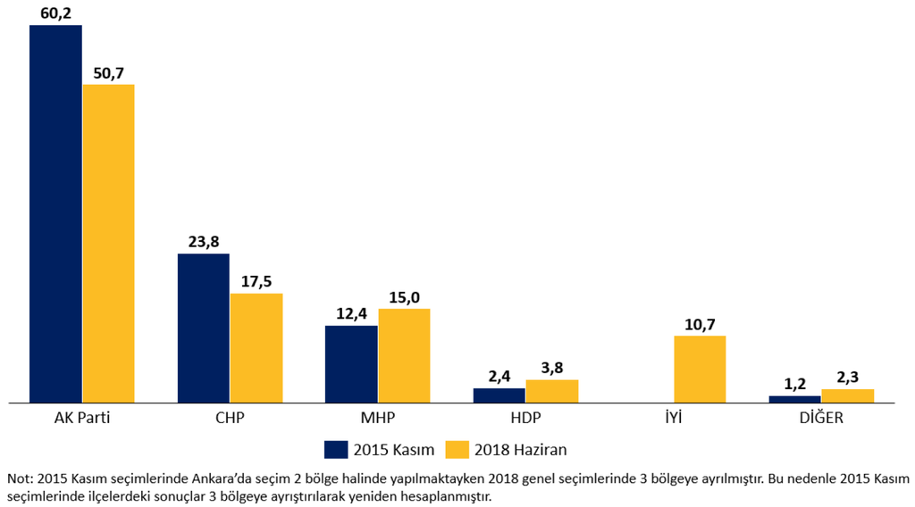

• 2015 Kasım seçimleri ile 2018 seçimleri arasında AK Parti ve CHP’de oy kayıpları yaşanırken MHP ve HDP’de oy artışı olmuştur.

• AK Parti, oylarının çoğunu MHP’ye, CHP ise oylarının bir kısımını İYİ Parti’ye bir kısmını ise HDP’ye kaybetmiştir.

• Akyurt, Altındağ, Çamlıdere, Çubuk, Kızılcahamam ve Pursaklar AK Parti’nin yüzden 10’dan fazla oy kaybettiği ilçeler olarak öne çıkmaktadır. MHP ise bu ilçelerde ortalama yüzde 5 oranında oyunu artırmıştır. Bu tablodan da görüldüğü üzere AK Parti’den ayrılan seçmen çoğunlukla MHP’ye yönelmiştir.

• Kalecik, Güdül, Keçiören’de CHP’den İyi Parti’ye yüzde 2,5 civarında oy geçişi tespit edilmiştir. Aynı zamanda Keçiören ve Pursaklar’da yine CHP’den HDP’ye yaklaşık yüzde 1 oranında oy geçişi vardır.

2018 yılında milletvekili seçimi sonuçlarının yanı sıra Cumhurbaşkanlığı seçimleri de yapıldı. Ortaya çıkan sonuçlar milletvekili seçimlerinden biraz daha farklıydı. Kimi adaylar partilerinden/ittifaklarından fazla oy alırken kimileri ise gerisinde kaldı.

### Ankara 2. Bölge 2018 Cumhurbaşkanlığı Seçim Sonuçları ve Analizi

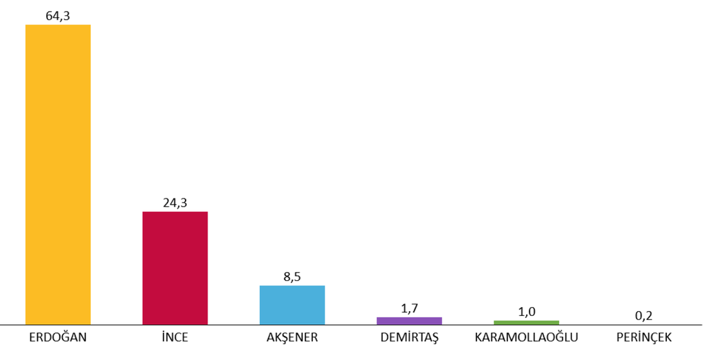

• 6 adaylı Cumhurbaşkanlığı seçimlerinde Ankara 2. Bölge’de Recep Tayyip Erdoğan yüzde 64,3 oy oranı ile en fazla oy alan aday oldu. Erdoğan, 2014 yılında yapılan Cumhurbaşkanlığı seçimlerinde ise Ankara 2. Bölge’den yüzde 64,9 oranında oy alarak yine en fazla oy alan adaydı.

• Muhalefet adaylarından Muharrem İnce yüzde 24,3, Meral Akşener yüzde 8,5, Temel Karamollaoğlu yüzde 1,0, Selahattin Demirtaş yüzde 1,7, Doğu Perinçek ise yüzde 0,2 oranında oy almıştır. • Recep Tayyip Erdoğan’ı destekleyen AK Parti, MHP ve Hüda-Par’ın milletvekili seçimlerinde Ankara 2. Bölge’deki toplam oyları yüzde 65,9 olmuştur. Erdoğan’ın oyları, destekçi partilerinin yüzde 1,6 gerisinde kalmıştır. Cumhur ittifakı ve Hüda-Par’a oy veren yaklaşık 16.560 seçmen Erdoğan’a oy vermemiştir.

• CHP adayı Muharrem İnce ise partisinden yüzde 7,0 daha fazla oy almıştır. Bu oran Türkiye geneli ile örtüşmektedir. Muharrem İnce’ye parti dışarısından İyi Parti ve HDP’den oy gelmiştir. Muharrem İnce, CHP’den 72.440 oy daha fazla almıştır.

• Selahattin Demirtaş’ın oyları HDP’den yüzde 2,1, Temel Karamollaoğlu’nun oyları Saadet Partisi’nden yüzde 0,9 daha az gerçekleşirken, Doğu Perinçek ise Vatan Partisi ile aynı oyu almıştır. 2015 Kasım ve 2018 genel seçimlerinde partilerin ilçe bazlı oy dağılımları aşağıdaki tablolarda gösterilmektedir.

### Kasım 2015 Ankara 2. Bölge İlçe Bazlı Milletvekili Seçim Sonuçları

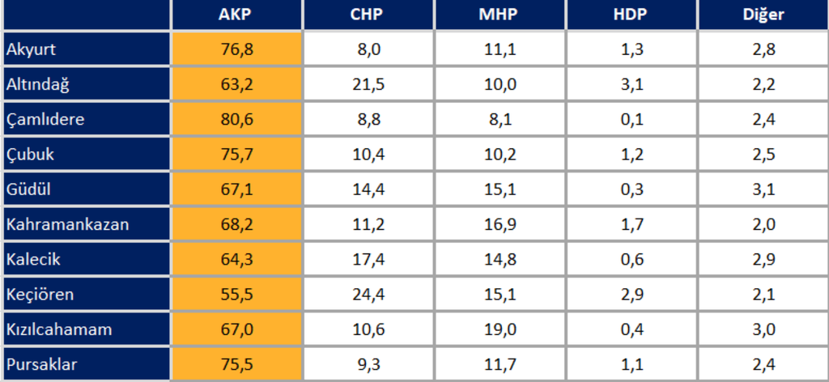

• 2015 Kasım seçimlerinde AK Parti 2. Bölgede Keçiören hariç bütün ilçelerde il ortalamasının üzerinde oy almıştır. 2. Bölge’de AK Parti’nin en yüksek oy aldığı ilçe yüzde 80,6 ile Çamlıdere olurken, en düşük oy aldığı ilçe yüzde 55,5 ile Keçiören olmuştur.

• CHP’nin oyları ise Keçiören ilçesi dışında diğer ilçelerde Ankara 2. Bölge ortalamanın gerisindedir. CHP en yüksek oy oranını yüzde 24,4 ile Keçiören’de elde ederken, yüzde 8,0 ile Akyurt’ta en düşük desteği görmüştür.

• MHP’de ki oy dağılımına bakıldığında Kızılcahamam, Kahramankazan, Güdül, Keçiören ve Kalecik en çok oy aldığı ilçeler ön plana çıkmaktadır. MHP, en fazla oyu yüzde 19,0 ile Kızılcahamam ilçesinden alırken, Çamlıdere’de yüzde 10’un altında kalmıştır.

### 2018 Ankara 2. Bölge İlçe Bazlı Milletvekili Seçim Sonuçları

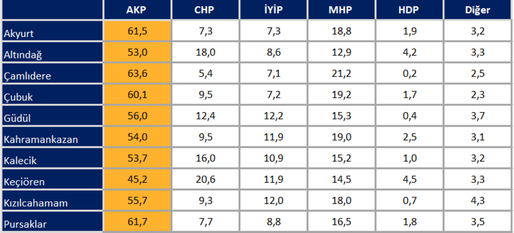

• 2018 genel seçimleri Ankara 2. Bölge genelinde AK Parti ve CHP’nin oy kaybına sahne oldu.

• AK Parti 2018 seçimlerinde, 2015 Kasım seçimlerine göre bütün ilçelerde oy kaybetmiştir. En fazla oy kaybettiği üç ilçe olan Çamlıdere, Çubuk ve Akyurt’ta her bir ilçe için oy kaybı yüzde 15,0’in üzerindedir.

• CHP’de AK Parti’ye benzer şekilde bütün ilçelerde oy kaybetmiş olup, en fazla oy kaybettiği ilçeler ise Keçiören, Altındağ ve Çamlıdere’dir. Akyurt ve Çubuk ilçeleri ise diğer ilçelere nazaran daha az oy kaybı yaşanan ilçeler olarak öne çıkmakta olup, iki ilçede ortalama kayıp yüzde 0,8’dir.

• Keçiören ve Kızılcahamam ilçeleri dışında diğer 2. Bölge ilçelerinde MHP oylarını artırmıştır. Yüzde 13,1 oy oranı ile Çamlıdere, yüzde 9,0 ile Çubuk ve yüzde 7,7 ile Akyurt ilçeleri MHP’nin en çok oy artırdığı ilçelerdir.

### 2018 Ankara 2. Bölge İlçe Bazlı Cumhurbaşkanlığı Seçim Sonuçları

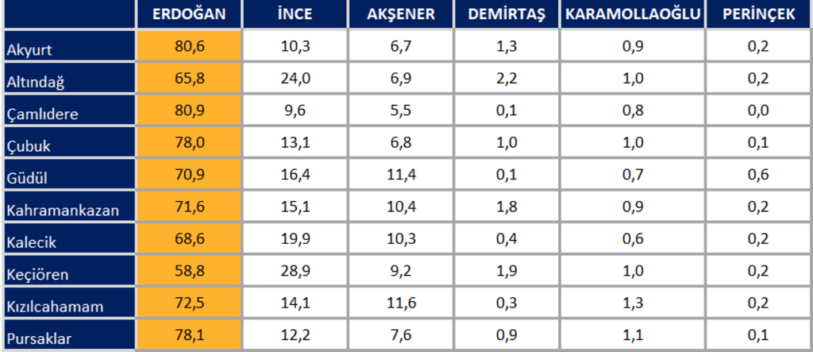

• Erdoğan’ın oyları Akyurt ve Çamlıdere’de yüzde 80’in üstüne ulaşırken Keçiören İlçesi Erdoğan’ın en az oy aldığı ilçe olmakla birlikte 2. Bölge ortalamasının gerisindedir. Kahramankazan, Kalecik, Keçiören ilçelerinde Erdoğan’ın oy oranı Cumhur İttifakının %2’den daha düşüktür.

• Muharrem İnce’nin oyları 2. Bölge’de CHP’den yüzde 7,0 daha fazla gerçekleşmiştir. İnce, Altındağ ve Keçiören’de yüzde 20’den fazla oy almıştır. Çamlıdere’de ise İnce, yüzde 10’u aşamamıştır.

• Meral Akşener’in oyları ise İyi Parti’nin 2,2 puan gerisinde kaldı. Kızılcahamam, Güdül, Kahramankazan ve Kalecik ilçelerinde Akşener yüzde 10’un üzerinde oy almıştır. Yüzde 5,5 ile Çamlıdere, yüzde 6,7 ile Akyurt, yüzde 6,9 ile Altındağ ilçeleri en az oy alınan ilçeler olarak tespit edilmiştir.

Nisan 2023 tarihi itibariyle yapılan genel seçim anketlerinin Ankara 2. Bölge özelinde hesaplanmasıyla beraber ortaya çıkan toplam verilerle ilçe bazlı beklenen sonuçlar ve muhtemel milletvekili dağılımı aşağıda tablo ve grafiklerde gösterilmektedir.

### Nisan 2023 İtibarıyla Ankara 2. Bölge 2023 Genel Seçim Tahminleri

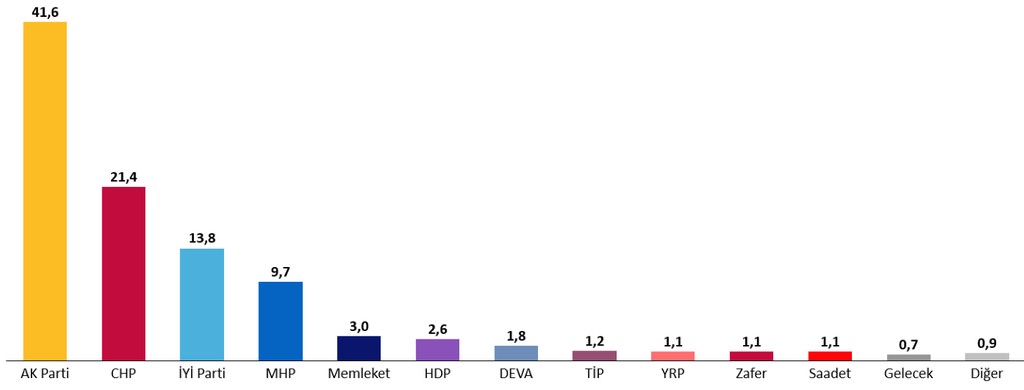

Cumhur ittifakı bileşenleri AK Parti ve MHP’de toplamda yüzde 14,4 oranında oy kaybı tahmin edilmektedir. Millet ittifakında ise yüzde 6,0 oranında oy artışı öngörülmektedir.

Yeni kurulan siyasi partilerden Memleket Partisi yüzde 3,0, Deva Partisi yüzde 1,8, Türkiye İşçi Partisi yüzde 1,2, Yeniden Refah Partisi ise yüzde 1,1 oy oranına ulaşmaktadır.

### Nisan 2023 İtibarıyla Ankara 2. Bölge İlçe Bazlı Genel Seçim Tahminleri

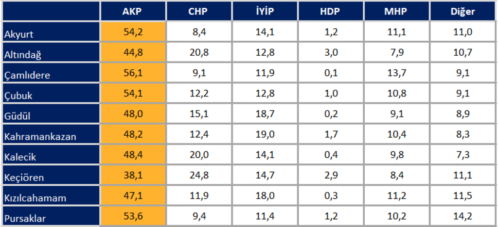

• Mevcut anket verileri ışığında Ankara 2. Bölgede partilerin beklenen oyları tabloda görüldüğü gibidir. Bugün itibarıyla tüm ilçelerde AK Parti’nin birinci parti olması muhtemel görünmekle birlikte 2023 tahminlerinde 2. Bölgedeki tüm ilçelerde 2018 genel seçimlerine göre oy kaybı yaşanacaktır. AK Parti’de en fazla oy kaybının Kızılcahamam’da yüzde 8,6, Altındağ’da 8,2 ve Pursaklar’da 8,1 olması beklenmektedir.

• CHP’nin ilçe performansları incelendiğinde tüm ilçelerde oy oranını artıracağı tahmin edilmektedir. Oy oranının en fazla artması beklenen ilçesi yüzde 4,2 ile Keçiören iken, en az artışısın yüzde 1,1 ile Akyurt’tan olması öngörülmektedir.

• İYİ Parti’nin oy potansiyelinin en güçlü olduğu ilçe yüzde 7,1 ile Kahramankazan’dır. Diğer yandan Akyurt, Güdül ve Kızılcahamam ilçeleri yüzde 6,0’nın üzerinde oy kazanma potansiyelini barındırmaktadır. Pursaklar ve Keçiören ilçeleri ise sırasıyla yüzde 2,6 ve yüzde 2,8 oran ile İyi Parti’nin oy oranını en az artırabileceği ilçeler olarak değerlendirilmektedir.

• MHP’nin, 2018 seçimlerine göre Ankara 2. Bölgede tüm ilçelerde oy kaybetmesi beklenmektedir. En fazla oy kaybetmesi beklenen ilçe yüzde 8,6’lık bir kayıpla İyi Parti’nin oy potansiyelinin güçlü olduğu Kahramankazan’dır. Benzer şekilde Çubuk, Akyurt ve Çamlıdere MHP’nin yüzde 7,0’nin üzerinde oy kaybı yaşayacağı ilçeler olarak öne çıkmakta, bu ilçeler aynı zamanda İyi Parti’nin seçim çalışmalarında önemli ilçeler olarak yer almaktadır.

## Parti Bazlı Analizler

Ankara 2. Bölgede siyasi aritmetiği ve geçmişe dönük sonuçları yukarıdaki grafik ve tablolar ile bildirdik. Bundan sonra verilecek haritalar ve tablolar ilçe bazlı olarak partilerin oy dağılımını ve 2023 genel seçimine yönelik sonuçları gösterecektir. AK Parti, CHP, MHP ve İyi Parti’ye dair 2018 genel seçim sonuçlarına ilişkin ilçe bazlı oy dağılımları aşağıda sıralanmıştır.

### AK Parti

#### İlçe Bazlı

[interactive chart not shown]

AK Partinin oyları Çubuk, Akyurt, Pursaklar ve Çamlıdere ilçelerinde yüzde 60,0’ın üzerine çıkmaktadır. Bu ilçeler AK Partinin Ankara 2. bölgede en güçlü olduğu alanlar olarak öne çıkmaktadır. Keçiören, Altındağ, Kalecik, Kahramankazan ise AK Parti’nin en düşük oy aldığı ilçeler olarak göze çarpmaktadır. Keçiören ise yüzde 45,2 oy oranı ile AK Parti’nin en zayıf olduğu ilçedir.

#### Mahalle Bazlı

[interactive chart not shown]

AK Partinin oyları Çubuk, Akyurt, Pursaklar ve Çamlıdere ilçelerinde yüzde 60,0’ın üzerine çıkmaktadır. Bu ilçeler AK Partinin Ankara 2. bölgede en güçlü olduğu alanlar olarak öne çıkmaktadır. Keçiören, Altındağ, Kalecik, Kahramankazan ise AK Parti’nin en düşük oy aldığı ilçeler olarak göze çarpmaktadır. Keçiören ise yüzde 45,2 oy oranı ile AK Parti’nin en zayıf olduğu ilçedir.

### CHP

#### İlçe Bazlı

[interactive chart not shown]

#### Mahalle Bazlı

[interactive chart not shown]

### İYİ Parti

#### İlçe Bazlı

[interactive chart not shown]

Oy dağılımları İyi Parti özelinde incelendiğinde Kalecik, Kahramankazan, Keçiören, Kızılcahamam ve Güdül’de yüzde 10,0’un oy potansiyeli yakalamıştır. 2018 genel seçimlerinde ilk defa seçimlere katılan İyi Parti’nin yüzde 10,4 oyunun, yüzde 8,4’ü MHP’den, yüzde 1’i CHP’den, yüzde 1’i ise AK Parti’den gelmektedir. Çamlıdere, Çubuk ve Akyurt ilçeleri İyi Parti’nin en az oy aldığı ilçeler olarak ön plana çıkmaktadır. Ankara 2. Bölgede tüm ilçelerde İyi Parti’nin oy oranı MHP’nin gerisinde kalmıştır. 2023 genel seçimlerinde İyi Parti’nin önem vermesi gereken ilçeler Çamlıdere, Çubuk, Akyurt, Altındağ ve Pursaklar olarak tespit edilmiştir.

#### Mahalle Bazlı

[interactive chart not shown]

Oy dağılımları İyi Parti özelinde incelendiğinde Kalecik, Kahramankazan, Keçiören, Kızılcahamam ve Güdül’de yüzde 10,0’un oy potansiyeli yakalamıştır. 2018 genel seçimlerinde ilk defa seçimlere katılan İyi Parti’nin yüzde 10,4 oyunun, yüzde 8,4’ü MHP’den, yüzde 1’i CHP’den, yüzde 1’i ise AK Parti’den gelmektedir. Çamlıdere, Çubuk ve Akyurt ilçeleri İyi Parti’nin en az oy aldığı ilçeler olarak ön plana çıkmaktadır. Ankara 2. Bölgede tüm ilçelerde İyi Parti’nin oy oranı MHP’nin gerisinde kalmıştır. 2023 genel seçimlerinde İyi Parti’nin önem vermesi gereken ilçeler Çamlıdere, Çubuk, Akyurt, Altındağ ve Pursaklar olarak tespit edilmiştir.

### MHP

#### İlçe Bazlı

[interactive chart not shown]

#### Mahalle Bazlı

[interactive chart not shown]

## Oy Geçişleri Üzerine Analizler

İlçe bazlı AK Parti seçmenlerinin muhalif partilere meyil etme durumları analiz edilmiştir. Haritalarda turuncu ile renklendirilen ilçelerde AK Partili seçmenler il ortalamasından daha çok muhalefete yönelmiştir. 2023 Milletvekili genel seçimlerinde turuncu renk ile gösterilen ilçelerde yapılacak olan seçim çalışmaları daha fazla etki gösterecektir. Belirlenen mahallelerde Cumhur ittifakı seçmenleri daha yoğundur ve İyi Parti için potansiyel oluşturmaktadır.

### AK Parti’nin 2015 Kasım-2018 Haziran Seçimleri Arasında yüzde 10’dan Fazla Oy Kaybettiği İlçeler

[interactive chart not shown]

Haritada turuncu renk ile gösterilen mahallelerde 2015 ve 2018 yıllarında gerçekleştirilen genel seçimlerde Ak Parti ortalamanın üzerinde oy kaybetmiştir. 2023 genel seçimlerinde de oy kaybetme potansiyeli yüksektir. Belirlenen mahalleler seçim sürecinde muhakkak ziyaret edilmeli ve seçim çalışmalarında yer almalıdır.

### AK Parti’nin 2011-2015 Haziran Arasında yüzde 12’den Daha Fazla Oy Kaybettiği Mahalleler

[interactive chart not shown]

Görselde gösterilen mahalleler Ak Parti’nin 2015 ve 2018 yıllarında gerçekleştirilen genel seçimlerde Türkiye ortalamasından ve Ankara 2. Bölge ortalamasından yüksek oy kaybettiği mahallelerdir. İyi Parti’nin Milletvekilliği seçimlerinde seçim çalışmalarında yer alması önemli mahallelerdir.

### MHP’nin 2015 Kasım - 2018 Arasında % 10’dan Fazla Oy Kazandığı Mahalleler

[interactive chart not shown]

Haritada mavi renk ile gösterilen mahallelerde 2015 ve 2018 yıllarında gerçekleştirilen genel seçimlerde Ak Parti ortalamanın üzerinde oy kaybetmiştir. 2023 genel seçimlerinde de oy kaybetme potansiyeli yüksektir. Belirlenen mahalleler aynı zamanda AK Parti’nin en fazla oy kaybettiği mahallelerdir. Bu mahalleler İyi Parti için çalışılması gereken muhtemel alanları ortaya koymaktadır.

### MHP’nin 2011-2015 Haziran Arasında %10’dan Fazla Oy Kazandığı Mahalleler

[interactive chart not shown]

Haritada mavi renk ile gösterilen mahallelerde MHP’nin oyları 2018 seçimlerinde 2015 Kasım’a göre yüzde 10’dan fazla artmıştır. İlgili mahallelerde MHP’nin AK Parti’den önemli ölçüde oy aldığı tespit edilmiştir. MHP’nin o dönemki muhalif tutumu göz önünde bulundurulduğunda AK Parti’den muhalefete oy geçişinin yüksek olduğu mahalleler görülmektedir ve 2023 seçimlerinde İyi Parti için potansiyel oluşturmaktadır.

### Meral Akşener’in İYİ Parti’den Daha Fazla Oy Aldığı Mahalleler

[interactive chart not shown]

Meral Akşener’in 2018 Cumhurbaşkanlığı seçiminde İyi Parti’den daha fazla oy aldığı mahalleler haritada mavi renk ile gösterilmiştir. İlgili mahalleler aynı zamanda MHP’nin Ankara 2. Bölgede il ortalamasından daha yüksek oy aldığı mahalleler olarak öne çıkmaktadır. 2023 Milletvekili seçimlerinde İyi Parti’nin oy artırma adına hamle yapacağı ilk mahalleler mavi renk ile gösterilen mahalleler olarak öne çıkmaktadır.

### MHP’nin 2015 Kasım’da %15’ten Fazla Oy Aldığı ve İYİ Parti’nin 2018’de %10’dan Az Oy Aldığı Mahalleler

[interactive chart not shown]

2015 Kasım seçimlerinde MHP’nin yüzde 15’ten fazla oy aldığı ancak İyi Parti’nin 2018’de %10’u aşamadığı mahalleler mavi renk ile gösterilmiştir. İlgili mahallelerdeki oyların dağılımı incelendiğinde 2018 Haziran seçimlerinde İyi Parti’nin MHP’den oluşan potansiyeli dolduramadığı saptanmış, 2023 genel seçimlerinde İyi Parti’nin hamle yapabileceği mahalleler olarak öne çıkmıştır.

## İlçelerde Hangi Mahallelere Öncelik Verilmeli

### Akyurt

#### İYİ Parti Oy Oranı

[interactive chart not shown]

Akyurt ilçesinde Ahmetadil, Beyazıt, Yeşiltepe, Yıldırım, Balıkhisar, Cücük, Elecik, Galaba, Kızık, Kozayağı ve Güzelhisar öncelik verilmesi gereken mahalleler olarak saptanmıştır. Belirtilen mahallelerde Cumhur ittifakı oyları yüzde 75-90 oranlarında ölçülmüştür. Milliyetçi seçmenin yoğunlukta olduğu tespit edilmiş olup, İyi Parti için belirlenen mahallelerde propaganda alanları geniş olarak bulunmaktadır. Belirlenen mahallelerin toplam seçmen sayısı 2018 genel seçimlerinde 17.269 olarak gerçekleşmiştir.

#### AKP 2015-2018

[interactive chart not shown]

Akyurt ilçesinde Ahmetadil, Beyazıt, Yeşiltepe, Yıldırım, Balıkhisar, Cücük, Elecik, Galaba, Kızık, Kozayağı ve Güzelhisar öncelik verilmesi gereken mahalleler olarak saptanmıştır. Belirtilen mahallelerde Cumhur ittifakı oyları yüzde 75-90 oranlarında ölçülmüştür. Milliyetçi seçmenin yoğunlukta olduğu tespit edilmiş olup, İyi Parti için belirlenen mahallelerde propaganda alanları geniş olarak bulunmaktadır. Belirlenen mahallelerin toplam seçmen sayısı 2018 genel seçimlerinde 17.269 olarak gerçekleşmiştir.

#### AKP 2011-2015

[interactive chart not shown]

Akyurt ilçesinde Ahmetadil, Beyazıt, Yeşiltepe, Yıldırım, Balıkhisar, Cücük, Elecik, Galaba, Kızık, Kozayağı ve Güzelhisar öncelik verilmesi gereken mahalleler olarak saptanmıştır. Belirtilen mahallelerde Cumhur ittifakı oyları yüzde 75-90 oranlarında ölçülmüştür. Milliyetçi seçmenin yoğunlukta olduğu tespit edilmiş olup, İyi Parti için belirlenen mahallelerde propaganda alanları geniş olarak bulunmaktadır. Belirlenen mahallelerin toplam seçmen sayısı 2018 genel seçimlerinde 17.269 olarak gerçekleşmiştir.

#### MHP 2015-2018

[interactive chart not shown]

Akyurt ilçesinde Ahmetadil, Beyazıt, Yeşiltepe, Yıldırım, Balıkhisar, Cücük, Elecik, Galaba, Kızık, Kozayağı ve Güzelhisar öncelik verilmesi gereken mahalleler olarak saptanmıştır. Belirtilen mahallelerde Cumhur ittifakı oyları yüzde 75-90 oranlarında ölçülmüştür. Milliyetçi seçmenin yoğunlukta olduğu tespit edilmiş olup, İyi Parti için belirlenen mahallelerde propaganda alanları geniş olarak bulunmaktadır. Belirlenen mahallelerin toplam seçmen sayısı 2018 genel seçimlerinde 17.269 olarak gerçekleşmiştir.

#### MHP 2011-2015

[interactive chart not shown]

Akyurt ilçesinde Ahmetadil, Beyazıt, Yeşiltepe, Yıldırım, Balıkhisar, Cücük, Elecik, Galaba, Kızık, Kozayağı ve Güzelhisar öncelik verilmesi gereken mahalleler olarak saptanmıştır. Belirtilen mahallelerde Cumhur ittifakı oyları yüzde 75-90 oranlarında ölçülmüştür. Milliyetçi seçmenin yoğunlukta olduğu tespit edilmiş olup, İyi Parti için belirlenen mahallelerde propaganda alanları geniş olarak bulunmaktadır. Belirlenen mahallelerin toplam seçmen sayısı 2018 genel seçimlerinde 17.269 olarak gerçekleşmiştir.

#### Meral Akşener- İYİ Parti

[interactive chart not shown]

Akyurt ilçesinde Ahmetadil, Beyazıt, Yeşiltepe, Yıldırım, Balıkhisar, Cücük, Elecik, Galaba, Kızık, Kozayağı ve Güzelhisar öncelik verilmesi gereken mahalleler olarak saptanmıştır. Belirtilen mahallelerde Cumhur ittifakı oyları yüzde 75-90 oranlarında ölçülmüştür. Milliyetçi seçmenin yoğunlukta olduğu tespit edilmiş olup, İyi Parti için belirlenen mahallelerde propaganda alanları geniş olarak bulunmaktadır. Belirlenen mahallelerin toplam seçmen sayısı 2018 genel seçimlerinde 17.269 olarak gerçekleşmiştir.

#### MHP - İYİ Parti

[interactive chart not shown]

Akyurt ilçesinde Ahmetadil, Beyazıt, Yeşiltepe, Yıldırım, Balıkhisar, Cücük, Elecik, Galaba, Kızık, Kozayağı ve Güzelhisar öncelik verilmesi gereken mahalleler olarak saptanmıştır. Belirtilen mahallelerde Cumhur ittifakı oyları yüzde 75-90 oranlarında ölçülmüştür. Milliyetçi seçmenin yoğunlukta olduğu tespit edilmiş olup, İyi Parti için belirlenen mahallelerde propaganda alanları geniş olarak bulunmaktadır. Belirlenen mahallelerin toplam seçmen sayısı 2018 genel seçimlerinde 17.269 olarak gerçekleşmiştir.

#### **Tüm seçili mahalleler**

[interactive chart not shown]

Akyurt ilçesinde Ahmetadil, Beyazıt, Yeşiltepe, Yıldırım, Balıkhisar, Cücük, Elecik, Galaba, Kızık, Kozayağı ve Güzelhisar öncelik verilmesi gereken mahalleler olarak saptanmıştır. Belirtilen mahallelerde Cumhur ittifakı oyları yüzde 75-90 oranlarında ölçülmüştür. Milliyetçi seçmenin yoğunlukta olduğu tespit edilmiş olup, İyi Parti için belirlenen mahallelerde propaganda alanları geniş olarak bulunmaktadır. Belirlenen mahallelerin toplam seçmen sayısı 2018 genel seçimlerinde 17.269 olarak gerçekleşmiştir.

### Altındağ

#### İYİ Parti Oy Oranı

[interactive chart not shown]

Altındağ ilçesi AK Parti’nin yüzde 53,0 oran ile önde olduğu bir ilçedir. İlçede MHP’nin oranı yüzde 12,9, İyi Parti’nin oy oranı ise yüzde 8,6 seviyesindedir. Altındağ İyi Parti’nin düşük oy aldığı ilçeler arasında yer almakta, Nisan 2023 itibarıyla hesaplanan simülasyonda yüzde 12,8 oy oranına ulaşacağı öngörülmektedir. İlçede İyi Parti için önümüzdeki dönemde Cumhur ittifakından oy alma potansiyelinin yüksek olduğu mahalleler: Baraj, Battalgazi, Bağlariçi, Başpınar, Doğantepe, Karacaören, Karapürçek, Ulubey, Solfasol, Yıldıztepe ve Önder mahalleleri olarak öne çıkmaktadır. İlçede İyi Parti’nin 17.000 yeni oy alması potansiyel dahilindedir. Belirlenen mahallelerde son seçimlerdeki toplam seçmen sayısı 105.560 olmuştur. İlçede İyi Parti’nin CHP’den oy alması potansiyeli olan mahalleler arasında Altınpark, Aydınlıkevler, Örnek, Ziraat ve Feridun Çeliktir öne çıkmaktadır

#### AKP 2015-2018

[interactive chart not shown]

Altındağ ilçesi AK Parti’nin yüzde 53,0 oran ile önde olduğu bir ilçedir. İlçede MHP’nin oranı yüzde 12,9, İyi Parti’nin oy oranı ise yüzde 8,6 seviyesindedir. Altındağ İyi Parti’nin düşük oy aldığı ilçeler arasında yer almakta, Nisan 2023 itibarıyla hesaplanan simülasyonda yüzde 12,8 oy oranına ulaşacağı öngörülmektedir. İlçede İyi Parti için önümüzdeki dönemde Cumhur ittifakından oy alma potansiyelinin yüksek olduğu mahalleler: Baraj, Battalgazi, Bağlariçi, Başpınar, Doğantepe, Karacaören, Karapürçek, Ulubey, Solfasol, Yıldıztepe ve Önder mahalleleri olarak öne çıkmaktadır. İlçede İyi Parti’nin 17.000 yeni oy alması potansiyel dahilindedir. Belirlenen mahallelerde son seçimlerdeki toplam seçmen sayısı 105.560 olmuştur. İlçede İyi Parti’nin CHP’den oy alması potansiyeli olan mahalleler arasında Altınpark, Aydınlıkevler, Örnek, Ziraat ve Feridun Çeliktir öne çıkmaktadır

#### AKP 2011-2015

[interactive chart not shown]

Altındağ ilçesi AK Parti’nin yüzde 53,0 oran ile önde olduğu bir ilçedir. İlçede MHP’nin oranı yüzde 12,9, İyi Parti’nin oy oranı ise yüzde 8,6 seviyesindedir. Altındağ İyi Parti’nin düşük oy aldığı ilçeler arasında yer almakta, Nisan 2023 itibarıyla hesaplanan simülasyonda yüzde 12,8 oy oranına ulaşacağı öngörülmektedir. İlçede İyi Parti için önümüzdeki dönemde Cumhur ittifakından oy alma potansiyelinin yüksek olduğu mahalleler: Baraj, Battalgazi, Bağlariçi, Başpınar, Doğantepe, Karacaören, Karapürçek, Ulubey, Solfasol, Yıldıztepe ve Önder mahalleleri olarak öne çıkmaktadır. İlçede İyi Parti’nin 17.000 yeni oy alması potansiyel dahilindedir. Belirlenen mahallelerde son seçimlerdeki toplam seçmen sayısı 105.560 olmuştur. İlçede İyi Parti’nin CHP’den oy alması potansiyeli olan mahalleler arasında Altınpark, Aydınlıkevler, Örnek, Ziraat ve Feridun Çeliktir öne çıkmaktadır

#### MHP 2015-2018

[interactive chart not shown]

Altındağ ilçesi AK Parti’nin yüzde 53,0 oran ile önde olduğu bir ilçedir. İlçede MHP’nin oranı yüzde 12,9, İyi Parti’nin oy oranı ise yüzde 8,6 seviyesindedir. Altındağ İyi Parti’nin düşük oy aldığı ilçeler arasında yer almakta, Nisan 2023 itibarıyla hesaplanan simülasyonda yüzde 12,8 oy oranına ulaşacağı öngörülmektedir. İlçede İyi Parti için önümüzdeki dönemde Cumhur ittifakından oy alma potansiyelinin yüksek olduğu mahalleler: Baraj, Battalgazi, Bağlariçi, Başpınar, Doğantepe, Karacaören, Karapürçek, Ulubey, Solfasol, Yıldıztepe ve Önder mahalleleri olarak öne çıkmaktadır. İlçede İyi Parti’nin 17.000 yeni oy alması potansiyel dahilindedir. Belirlenen mahallelerde son seçimlerdeki toplam seçmen sayısı 105.560 olmuştur. İlçede İyi Parti’nin CHP’den oy alması potansiyeli olan mahalleler arasında Altınpark, Aydınlıkevler, Örnek, Ziraat ve Feridun Çeliktir öne çıkmaktadır

#### MHP 2011-2015

[interactive chart not shown]

Altındağ ilçesi AK Parti’nin yüzde 53,0 oran ile önde olduğu bir ilçedir. İlçede MHP’nin oranı yüzde 12,9, İyi Parti’nin oy oranı ise yüzde 8,6 seviyesindedir. Altındağ İyi Parti’nin düşük oy aldığı ilçeler arasında yer almakta, Nisan 2023 itibarıyla hesaplanan simülasyonda yüzde 12,8 oy oranına ulaşacağı öngörülmektedir. İlçede İyi Parti için önümüzdeki dönemde Cumhur ittifakından oy alma potansiyelinin yüksek olduğu mahalleler: Baraj, Battalgazi, Bağlariçi, Başpınar, Doğantepe, Karacaören, Karapürçek, Ulubey, Solfasol, Yıldıztepe ve Önder mahalleleri olarak öne çıkmaktadır. İlçede İyi Parti’nin 17.000 yeni oy alması potansiyel dahilindedir. Belirlenen mahallelerde son seçimlerdeki toplam seçmen sayısı 105.560 olmuştur. İlçede İyi Parti’nin CHP’den oy alması potansiyeli olan mahalleler arasında Altınpark, Aydınlıkevler, Örnek, Ziraat ve Feridun Çeliktir öne çıkmaktadır

#### Meral Akşener- İYİ Parti

[interactive chart not shown]

Altındağ ilçesi AK Parti’nin yüzde 53,0 oran ile önde olduğu bir ilçedir. İlçede MHP’nin oranı yüzde 12,9, İyi Parti’nin oy oranı ise yüzde 8,6 seviyesindedir. Altındağ İyi Parti’nin düşük oy aldığı ilçeler arasında yer almakta, Nisan 2023 itibarıyla hesaplanan simülasyonda yüzde 12,8 oy oranına ulaşacağı öngörülmektedir. İlçede İyi Parti için önümüzdeki dönemde Cumhur ittifakından oy alma potansiyelinin yüksek olduğu mahalleler: Baraj, Battalgazi, Bağlariçi, Başpınar, Doğantepe, Karacaören, Karapürçek, Ulubey, Solfasol, Yıldıztepe ve Önder mahalleleri olarak öne çıkmaktadır. İlçede İyi Parti’nin 17.000 yeni oy alması potansiyel dahilindedir. Belirlenen mahallelerde son seçimlerdeki toplam seçmen sayısı 105.560 olmuştur. İlçede İyi Parti’nin CHP’den oy alması potansiyeli olan mahalleler arasında Altınpark, Aydınlıkevler, Örnek, Ziraat ve Feridun Çeliktir öne çıkmaktadır

#### MHP - İYİ Parti

[interactive chart not shown]

Altındağ ilçesi AK Parti’nin yüzde 53,0 oran ile önde olduğu bir ilçedir. İlçede MHP’nin oranı yüzde 12,9, İyi Parti’nin oy oranı ise yüzde 8,6 seviyesindedir. Altındağ İyi Parti’nin düşük oy aldığı ilçeler arasında yer almakta, Nisan 2023 itibarıyla hesaplanan simülasyonda yüzde 12,8 oy oranına ulaşacağı öngörülmektedir. İlçede İyi Parti için önümüzdeki dönemde Cumhur ittifakından oy alma potansiyelinin yüksek olduğu mahalleler: Baraj, Battalgazi, Bağlariçi, Başpınar, Doğantepe, Karacaören, Karapürçek, Ulubey, Solfasol, Yıldıztepe ve Önder mahalleleri olarak öne çıkmaktadır. İlçede İyi Parti’nin 17.000 yeni oy alması potansiyel dahilindedir. Belirlenen mahallelerde son seçimlerdeki toplam seçmen sayısı 105.560 olmuştur. İlçede İyi Parti’nin CHP’den oy alması potansiyeli olan mahalleler arasında Altınpark, Aydınlıkevler, Örnek, Ziraat ve Feridun Çeliktir öne çıkmaktadır

#### **Tüm seçili mahalleler**

[interactive chart not shown]

Altındağ ilçesi AK Parti’nin yüzde 53,0 oran ile önde olduğu bir ilçedir. İlçede MHP’nin oranı yüzde 12,9, İyi Parti’nin oy oranı ise yüzde 8,6 seviyesindedir. Altındağ İyi Parti’nin düşük oy aldığı ilçeler arasında yer almakta, Nisan 2023 itibarıyla hesaplanan simülasyonda yüzde 12,8 oy oranına ulaşacağı öngörülmektedir. İlçede İyi Parti için önümüzdeki dönemde Cumhur ittifakından oy alma potansiyelinin yüksek olduğu mahalleler: Baraj, Battalgazi, Bağlariçi, Başpınar, Doğantepe, Karacaören, Karapürçek, Ulubey, Solfasol, Yıldıztepe ve Önder mahalleleri olarak öne çıkmaktadır. İlçede İyi Parti’nin 17.000 yeni oy alması potansiyel dahilindedir. Belirlenen mahallelerde son seçimlerdeki toplam seçmen sayısı 105.560 olmuştur. İlçede İyi Parti’nin CHP’den oy alması potansiyeli olan mahalleler arasında Altınpark, Aydınlıkevler, Örnek, Ziraat ve Feridun Çeliktir öne çıkmaktadır

### Çamlıdere

#### İYİ Parti Oy Oranı

[interactive chart not shown]

Çamlıdere ilçesi Ak Parti’nin yüzde 63,6 oran ile en yüksek oy aldığı ilçe olmanın yanı sıra İyi Parti’nin de yüzde 7,1 oy oranı ile en düşük oy aldığı ilçedir. MHP’nin oyları ilçede yüzde 21,2 seviyesindedir. Dörtkonak, Doğanlar, Kayabaşı, Osmansin, Muzrupağacın, Yılanlı, Sarıkavak, Yayalar mahalleleri İyi Parti için ilçede potansiyeli yüksek ilçeler olarak öne çıkmaktadır. Belirlenen mahallelerin son seçimlerdeki toplam seçmen sayısı 2.885 olmuştur. İlçede İyi Parti’nin 300 yeni oy alması potansiyel dahilindedir.

#### AKP 2015-2018

[interactive chart not shown]

Çamlıdere ilçesi Ak Parti’nin yüzde 63,6 oran ile en yüksek oy aldığı ilçe olmanın yanı sıra İyi Parti’nin de yüzde 7,1 oy oranı ile en düşük oy aldığı ilçedir. MHP’nin oyları ilçede yüzde 21,2 seviyesindedir. Dörtkonak, Doğanlar, Kayabaşı, Osmansin, Muzrupağacın, Yılanlı, Sarıkavak, Yayalar mahalleleri İyi Parti için ilçede potansiyeli yüksek ilçeler olarak öne çıkmaktadır. Belirlenen mahallelerin son seçimlerdeki toplam seçmen sayısı 2.885 olmuştur. İlçede İyi Parti’nin 300 yeni oy alması potansiyel dahilindedir.

#### AKP 2011-2015

[interactive chart not shown]

Çamlıdere ilçesi Ak Parti’nin yüzde 63,6 oran ile en yüksek oy aldığı ilçe olmanın yanı sıra İyi Parti’nin de yüzde 7,1 oy oranı ile en düşük oy aldığı ilçedir. MHP’nin oyları ilçede yüzde 21,2 seviyesindedir. Dörtkonak, Doğanlar, Kayabaşı, Osmansin, Muzrupağacın, Yılanlı, Sarıkavak, Yayalar mahalleleri İyi Parti için ilçede potansiyeli yüksek ilçeler olarak öne çıkmaktadır. Belirlenen mahallelerin son seçimlerdeki toplam seçmen sayısı 2.885 olmuştur. İlçede İyi Parti’nin 300 yeni oy alması potansiyel dahilindedir.

#### MHP 2015-2018

[interactive chart not shown]

Çamlıdere ilçesi Ak Parti’nin yüzde 63,6 oran ile en yüksek oy aldığı ilçe olmanın yanı sıra İyi Parti’nin de yüzde 7,1 oy oranı ile en düşük oy aldığı ilçedir. MHP’nin oyları ilçede yüzde 21,2 seviyesindedir. Dörtkonak, Doğanlar, Kayabaşı, Osmansin, Muzrupağacın, Yılanlı, Sarıkavak, Yayalar mahalleleri İyi Parti için ilçede potansiyeli yüksek ilçeler olarak öne çıkmaktadır. Belirlenen mahallelerin son seçimlerdeki toplam seçmen sayısı 2.885 olmuştur. İlçede İyi Parti’nin 300 yeni oy alması potansiyel dahilindedir.

#### MHP 2011-2015

[interactive chart not shown]

Çamlıdere ilçesi Ak Parti’nin yüzde 63,6 oran ile en yüksek oy aldığı ilçe olmanın yanı sıra İyi Parti’nin de yüzde 7,1 oy oranı ile en düşük oy aldığı ilçedir. MHP’nin oyları ilçede yüzde 21,2 seviyesindedir. Dörtkonak, Doğanlar, Kayabaşı, Osmansin, Muzrupağacın, Yılanlı, Sarıkavak, Yayalar mahalleleri İyi Parti için ilçede potansiyeli yüksek ilçeler olarak öne çıkmaktadır. Belirlenen mahallelerin son seçimlerdeki toplam seçmen sayısı 2.885 olmuştur. İlçede İyi Parti’nin 300 yeni oy alması potansiyel dahilindedir.

#### Meral Akşener- İYİ Parti

[interactive chart not shown]

Çamlıdere ilçesi Ak Parti’nin yüzde 63,6 oran ile en yüksek oy aldığı ilçe olmanın yanı sıra İyi Parti’nin de yüzde 7,1 oy oranı ile en düşük oy aldığı ilçedir. MHP’nin oyları ilçede yüzde 21,2 seviyesindedir. Dörtkonak, Doğanlar, Kayabaşı, Osmansin, Muzrupağacın, Yılanlı, Sarıkavak, Yayalar mahalleleri İyi Parti için ilçede potansiyeli yüksek ilçeler olarak öne çıkmaktadır. Belirlenen mahallelerin son seçimlerdeki toplam seçmen sayısı 2.885 olmuştur. İlçede İyi Parti’nin 300 yeni oy alması potansiyel dahilindedir.

#### MHP - İYİ Parti

[interactive chart not shown]

Çamlıdere ilçesi Ak Parti’nin yüzde 63,6 oran ile en yüksek oy aldığı ilçe olmanın yanı sıra İyi Parti’nin de yüzde 7,1 oy oranı ile en düşük oy aldığı ilçedir. MHP’nin oyları ilçede yüzde 21,2 seviyesindedir. Dörtkonak, Doğanlar, Kayabaşı, Osmansin, Muzrupağacın, Yılanlı, Sarıkavak, Yayalar mahalleleri İyi Parti için ilçede potansiyeli yüksek ilçeler olarak öne çıkmaktadır. Belirlenen mahallelerin son seçimlerdeki toplam seçmen sayısı 2.885 olmuştur. İlçede İyi Parti’nin 300 yeni oy alması potansiyel dahilindedir.

#### **Tüm seçili mahalleler**

[interactive chart not shown]

Çamlıdere ilçesi Ak Parti’nin yüzde 63,6 oran ile en yüksek oy aldığı ilçe olmanın yanı sıra İyi Parti’nin de yüzde 7,1 oy oranı ile en düşük oy aldığı ilçedir. MHP’nin oyları ilçede yüzde 21,2 seviyesindedir. Dörtkonak, Doğanlar, Kayabaşı, Osmansin, Muzrupağacın, Yılanlı, Sarıkavak, Yayalar mahalleleri İyi Parti için ilçede potansiyeli yüksek ilçeler olarak öne çıkmaktadır. Belirlenen mahallelerin son seçimlerdeki toplam seçmen sayısı 2.885 olmuştur. İlçede İyi Parti’nin 300 yeni oy alması potansiyel dahilindedir.

### Çubuk

#### İYİ Parti Oy Oranı

[interactive chart not shown]

#### AKP 2015-2018

[interactive chart not shown]

#### AKP 2011-2015

[interactive chart not shown]

#### MHP 2015-2018

[interactive chart not shown]

#### MHP 2011-2015

[interactive chart not shown]

#### Meral Akşener- İYİ Parti

[interactive chart not shown]

#### MHP - İYİ Parti

[interactive chart not shown]

#### **Tüm seçili mahalleler**

[interactive chart not shown]

### Güdül

#### İYİ Parti Oy Oranı

[interactive chart not shown]

2018 genel seçimlerinde Ak Parti’nin en düşük oy aldığı ilçelerden biri olan Güdül, İyi Parti’nin ise en yüksek oy aldığı ilçedir. CHP’den İyi Parti’ye yüzde 2,5 civarında oy geçişi tespit edilmiştir. Aynı seçimde İyi Parti MHP’den yüzde 9,5 oy almıştır. 2023 genel seçimlerinde İyi Parti için Akçakese, Çağa, Garipçe, Güneyce, Sorgun, Salihler, Karacaören ve Aşağı mahalleleri önem arz etmektedir. Belirlenen mahalleler İyi Parti için 260 yeni oy potansiyeli içermektedir. Belirlenen mahalle ve köylerin son seçimlerdeki toplam seçmen sayısı 2.400 olmuştur.

#### AKP 2015-2018

[interactive chart not shown]

2018 genel seçimlerinde Ak Parti’nin en düşük oy aldığı ilçelerden biri olan Güdül, İyi Parti’nin ise en yüksek oy aldığı ilçedir. CHP’den İyi Parti’ye yüzde 2,5 civarında oy geçişi tespit edilmiştir. Aynı seçimde İyi Parti MHP’den yüzde 9,5 oy almıştır. 2023 genel seçimlerinde İyi Parti için Akçakese, Çağa, Garipçe, Güneyce, Sorgun, Salihler, Karacaören ve Aşağı mahalleleri önem arz etmektedir. Belirlenen mahalleler İyi Parti için 260 yeni oy potansiyeli içermektedir. Belirlenen mahalle ve köylerin son seçimlerdeki toplam seçmen sayısı 2.400 olmuştur.

#### AKP 2011-2015

[interactive chart not shown]

2018 genel seçimlerinde Ak Parti’nin en düşük oy aldığı ilçelerden biri olan Güdül, İyi Parti’nin ise en yüksek oy aldığı ilçedir. CHP’den İyi Parti’ye yüzde 2,5 civarında oy geçişi tespit edilmiştir. Aynı seçimde İyi Parti MHP’den yüzde 9,5 oy almıştır. 2023 genel seçimlerinde İyi Parti için Akçakese, Çağa, Garipçe, Güneyce, Sorgun, Salihler, Karacaören ve Aşağı mahalleleri önem arz etmektedir. Belirlenen mahalleler İyi Parti için 260 yeni oy potansiyeli içermektedir. Belirlenen mahalle ve köylerin son seçimlerdeki toplam seçmen sayısı 2.400 olmuştur.

#### MHP 2015-2018

[interactive chart not shown]

2018 genel seçimlerinde Ak Parti’nin en düşük oy aldığı ilçelerden biri olan Güdül, İyi Parti’nin ise en yüksek oy aldığı ilçedir. CHP’den İyi Parti’ye yüzde 2,5 civarında oy geçişi tespit edilmiştir. Aynı seçimde İyi Parti MHP’den yüzde 9,5 oy almıştır. 2023 genel seçimlerinde İyi Parti için Akçakese, Çağa, Garipçe, Güneyce, Sorgun, Salihler, Karacaören ve Aşağı mahalleleri önem arz etmektedir. Belirlenen mahalleler İyi Parti için 260 yeni oy potansiyeli içermektedir. Belirlenen mahalle ve köylerin son seçimlerdeki toplam seçmen sayısı 2.400 olmuştur.

#### MHP 2011-2015

[interactive chart not shown]

2018 genel seçimlerinde Ak Parti’nin en düşük oy aldığı ilçelerden biri olan Güdül, İyi Parti’nin ise en yüksek oy aldığı ilçedir. CHP’den İyi Parti’ye yüzde 2,5 civarında oy geçişi tespit edilmiştir. Aynı seçimde İyi Parti MHP’den yüzde 9,5 oy almıştır. 2023 genel seçimlerinde İyi Parti için Akçakese, Çağa, Garipçe, Güneyce, Sorgun, Salihler, Karacaören ve Aşağı mahalleleri önem arz etmektedir. Belirlenen mahalleler İyi Parti için 260 yeni oy potansiyeli içermektedir. Belirlenen mahalle ve köylerin son seçimlerdeki toplam seçmen sayısı 2.400 olmuştur.

#### Meral Akşener- İYİ Parti

[interactive chart not shown]

2018 genel seçimlerinde Ak Parti’nin en düşük oy aldığı ilçelerden biri olan Güdül, İyi Parti’nin ise en yüksek oy aldığı ilçedir. CHP’den İyi Parti’ye yüzde 2,5 civarında oy geçişi tespit edilmiştir. Aynı seçimde İyi Parti MHP’den yüzde 9,5 oy almıştır. 2023 genel seçimlerinde İyi Parti için Akçakese, Çağa, Garipçe, Güneyce, Sorgun, Salihler, Karacaören ve Aşağı mahalleleri önem arz etmektedir. Belirlenen mahalleler İyi Parti için 260 yeni oy potansiyeli içermektedir. Belirlenen mahalle ve köylerin son seçimlerdeki toplam seçmen sayısı 2.400 olmuştur.

#### MHP - İYİ Parti

[interactive chart not shown]

2018 genel seçimlerinde Ak Parti’nin en düşük oy aldığı ilçelerden biri olan Güdül, İyi Parti’nin ise en yüksek oy aldığı ilçedir. CHP’den İyi Parti’ye yüzde 2,5 civarında oy geçişi tespit edilmiştir. Aynı seçimde İyi Parti MHP’den yüzde 9,5 oy almıştır. 2023 genel seçimlerinde İyi Parti için Akçakese, Çağa, Garipçe, Güneyce, Sorgun, Salihler, Karacaören ve Aşağı mahalleleri önem arz etmektedir. Belirlenen mahalleler İyi Parti için 260 yeni oy potansiyeli içermektedir. Belirlenen mahalle ve köylerin son seçimlerdeki toplam seçmen sayısı 2.400 olmuştur.

#### **Tüm seçili mahalleler**

[interactive chart not shown]

2018 genel seçimlerinde Ak Parti’nin en düşük oy aldığı ilçelerden biri olan Güdül, İyi Parti’nin ise en yüksek oy aldığı ilçedir. CHP’den İyi Parti’ye yüzde 2,5 civarında oy geçişi tespit edilmiştir. Aynı seçimde İyi Parti MHP’den yüzde 9,5 oy almıştır. 2023 genel seçimlerinde İyi Parti için Akçakese, Çağa, Garipçe, Güneyce, Sorgun, Salihler, Karacaören ve Aşağı mahalleleri önem arz etmektedir. Belirlenen mahalleler İyi Parti için 260 yeni oy potansiyeli içermektedir. Belirlenen mahalle ve köylerin son seçimlerdeki toplam seçmen sayısı 2.400 olmuştur.

### Kahramankazan

#### İYİ Parti Oy Oranı

[interactive chart not shown]

Kahramankazan ilçesi Ak Parti’nin yüzde 54,0 oy oranı ile az oy aldığı ilçelerden biridir. İlçede MHP’nin oranı yüzde 19,0, İyi Parti’nin oy oranı ise yüzde 11,9’dur. İlçede İyi Parti için önümüzdeki dönemde Cumhur İttifakından oy alma potansiyelinin yüksek olduğu mahalleler: Atatürk, Fatih, Kayı, Satıkadın, İmrendi, Fethiye, Kılıçlar, Tekke olarak öne çıkmaktadır. Akıncı mahallesi ise CHP’den oy alma potansiyelinin yüksek olduğu ilçedir. İlçede İyi Parti’nin 1.250 yeni oy alması potansiyel dahilindedir. Belirlenen mahalle ve köylerin son seçimlerdeki toplam seçmen sayısı 10.200 olmuştur.

#### AKP 2015-2018

[interactive chart not shown]

Kahramankazan ilçesi Ak Parti’nin yüzde 54,0 oy oranı ile az oy aldığı ilçelerden biridir. İlçede MHP’nin oranı yüzde 19,0, İyi Parti’nin oy oranı ise yüzde 11,9’dur. İlçede İyi Parti için önümüzdeki dönemde Cumhur İttifakından oy alma potansiyelinin yüksek olduğu mahalleler: Atatürk, Fatih, Kayı, Satıkadın, İmrendi, Fethiye, Kılıçlar, Tekke olarak öne çıkmaktadır. Akıncı mahallesi ise CHP’den oy alma potansiyelinin yüksek olduğu ilçedir. İlçede İyi Parti’nin 1.250 yeni oy alması potansiyel dahilindedir. Belirlenen mahalle ve köylerin son seçimlerdeki toplam seçmen sayısı 10.200 olmuştur.

#### AKP 2011-2015

[interactive chart not shown]

Kahramankazan ilçesi Ak Parti’nin yüzde 54,0 oy oranı ile az oy aldığı ilçelerden biridir. İlçede MHP’nin oranı yüzde 19,0, İyi Parti’nin oy oranı ise yüzde 11,9’dur. İlçede İyi Parti için önümüzdeki dönemde Cumhur İttifakından oy alma potansiyelinin yüksek olduğu mahalleler: Atatürk, Fatih, Kayı, Satıkadın, İmrendi, Fethiye, Kılıçlar, Tekke olarak öne çıkmaktadır. Akıncı mahallesi ise CHP’den oy alma potansiyelinin yüksek olduğu ilçedir. İlçede İyi Parti’nin 1.250 yeni oy alması potansiyel dahilindedir. Belirlenen mahalle ve köylerin son seçimlerdeki toplam seçmen sayısı 10.200 olmuştur.

#### MHP 2015-2018

[interactive chart not shown]

Kahramankazan ilçesi Ak Parti’nin yüzde 54,0 oy oranı ile az oy aldığı ilçelerden biridir. İlçede MHP’nin oranı yüzde 19,0, İyi Parti’nin oy oranı ise yüzde 11,9’dur. İlçede İyi Parti için önümüzdeki dönemde Cumhur İttifakından oy alma potansiyelinin yüksek olduğu mahalleler: Atatürk, Fatih, Kayı, Satıkadın, İmrendi, Fethiye, Kılıçlar, Tekke olarak öne çıkmaktadır. Akıncı mahallesi ise CHP’den oy alma potansiyelinin yüksek olduğu ilçedir. İlçede İyi Parti’nin 1.250 yeni oy alması potansiyel dahilindedir. Belirlenen mahalle ve köylerin son seçimlerdeki toplam seçmen sayısı 10.200 olmuştur.

#### MHP 2011-2015

[interactive chart not shown]

Kahramankazan ilçesi Ak Parti’nin yüzde 54,0 oy oranı ile az oy aldığı ilçelerden biridir. İlçede MHP’nin oranı yüzde 19,0, İyi Parti’nin oy oranı ise yüzde 11,9’dur. İlçede İyi Parti için önümüzdeki dönemde Cumhur İttifakından oy alma potansiyelinin yüksek olduğu mahalleler: Atatürk, Fatih, Kayı, Satıkadın, İmrendi, Fethiye, Kılıçlar, Tekke olarak öne çıkmaktadır. Akıncı mahallesi ise CHP’den oy alma potansiyelinin yüksek olduğu ilçedir. İlçede İyi Parti’nin 1.250 yeni oy alması potansiyel dahilindedir. Belirlenen mahalle ve köylerin son seçimlerdeki toplam seçmen sayısı 10.200 olmuştur.

#### Meral Akşener- İYİ Parti

[interactive chart not shown]

Kahramankazan ilçesi Ak Parti’nin yüzde 54,0 oy oranı ile az oy aldığı ilçelerden biridir. İlçede MHP’nin oranı yüzde 19,0, İyi Parti’nin oy oranı ise yüzde 11,9’dur. İlçede İyi Parti için önümüzdeki dönemde Cumhur İttifakından oy alma potansiyelinin yüksek olduğu mahalleler: Atatürk, Fatih, Kayı, Satıkadın, İmrendi, Fethiye, Kılıçlar, Tekke olarak öne çıkmaktadır. Akıncı mahallesi ise CHP’den oy alma potansiyelinin yüksek olduğu ilçedir. İlçede İyi Parti’nin 1.250 yeni oy alması potansiyel dahilindedir. Belirlenen mahalle ve köylerin son seçimlerdeki toplam seçmen sayısı 10.200 olmuştur.

#### MHP - İYİ Parti

[interactive chart not shown]

Kahramankazan ilçesi Ak Parti’nin yüzde 54,0 oy oranı ile az oy aldığı ilçelerden biridir. İlçede MHP’nin oranı yüzde 19,0, İyi Parti’nin oy oranı ise yüzde 11,9’dur. İlçede İyi Parti için önümüzdeki dönemde Cumhur İttifakından oy alma potansiyelinin yüksek olduğu mahalleler: Atatürk, Fatih, Kayı, Satıkadın, İmrendi, Fethiye, Kılıçlar, Tekke olarak öne çıkmaktadır. Akıncı mahallesi ise CHP’den oy alma potansiyelinin yüksek olduğu ilçedir. İlçede İyi Parti’nin 1.250 yeni oy alması potansiyel dahilindedir. Belirlenen mahalle ve köylerin son seçimlerdeki toplam seçmen sayısı 10.200 olmuştur.

#### **Tüm seçili mahalleler**

[interactive chart not shown]

Kahramankazan ilçesi Ak Parti’nin yüzde 54,0 oy oranı ile az oy aldığı ilçelerden biridir. İlçede MHP’nin oranı yüzde 19,0, İyi Parti’nin oy oranı ise yüzde 11,9’dur. İlçede İyi Parti için önümüzdeki dönemde Cumhur İttifakından oy alma potansiyelinin yüksek olduğu mahalleler: Atatürk, Fatih, Kayı, Satıkadın, İmrendi, Fethiye, Kılıçlar, Tekke olarak öne çıkmaktadır. Akıncı mahallesi ise CHP’den oy alma potansiyelinin yüksek olduğu ilçedir. İlçede İyi Parti’nin 1.250 yeni oy alması potansiyel dahilindedir. Belirlenen mahalle ve köylerin son seçimlerdeki toplam seçmen sayısı 10.200 olmuştur.

### Kalecik

#### İYİ Parti Oy Oranı

[interactive chart not shown]

Kalecik ilçesinde AK Parti’nin oy oranı yüzde 53,7, MHP’nin oyları da yüzde 15,0 seviyesinde tespit edilmiştir. İyi Parti ise ilçede yüzde 10,9 oy almıştır. Ahikemalşenyurt ve Yenidoğan Şenyurt mahalleleri İyi Parti için ilçede CHP’den oy potansiyeli yüksek ilçeler olarak öne çıkmaktadır. Ayrıca, Yenidoğan, Yeşilyurt, Çanşakale, Halitcevriaslangil, Hacıköy, Samanlık, Yurtyenice mahalleleri Cumhur İttifakından oy alma potansiyeli içeren alanlardır. Belirlenen mahalle ve köylerin son seçimlerdeki toplam seçmen sayısı 4.200 olmuştur.

#### AKP 2015-2018

[interactive chart not shown]

Kalecik ilçesinde AK Parti’nin oy oranı yüzde 53,7, MHP’nin oyları da yüzde 15,0 seviyesinde tespit edilmiştir. İyi Parti ise ilçede yüzde 10,9 oy almıştır. Ahikemalşenyurt ve Yenidoğan Şenyurt mahalleleri İyi Parti için ilçede CHP’den oy potansiyeli yüksek ilçeler olarak öne çıkmaktadır. Ayrıca, Yenidoğan, Yeşilyurt, Çanşakale, Halitcevriaslangil, Hacıköy, Samanlık, Yurtyenice mahalleleri Cumhur İttifakından oy alma potansiyeli içeren alanlardır. Belirlenen mahalle ve köylerin son seçimlerdeki toplam seçmen sayısı 4.200 olmuştur.

#### AKP 2011-2015

[interactive chart not shown]

Kalecik ilçesinde AK Parti’nin oy oranı yüzde 53,7, MHP’nin oyları da yüzde 15,0 seviyesinde tespit edilmiştir. İyi Parti ise ilçede yüzde 10,9 oy almıştır. Ahikemalşenyurt ve Yenidoğan Şenyurt mahalleleri İyi Parti için ilçede CHP’den oy potansiyeli yüksek ilçeler olarak öne çıkmaktadır. Ayrıca, Yenidoğan, Yeşilyurt, Çanşakale, Halitcevriaslangil, Hacıköy, Samanlık, Yurtyenice mahalleleri Cumhur İttifakından oy alma potansiyeli içeren alanlardır. Belirlenen mahalle ve köylerin son seçimlerdeki toplam seçmen sayısı 4.200 olmuştur.

#### MHP 2015-2018

[interactive chart not shown]

Kalecik ilçesinde AK Parti’nin oy oranı yüzde 53,7, MHP’nin oyları da yüzde 15,0 seviyesinde tespit edilmiştir. İyi Parti ise ilçede yüzde 10,9 oy almıştır. Ahikemalşenyurt ve Yenidoğan Şenyurt mahalleleri İyi Parti için ilçede CHP’den oy potansiyeli yüksek ilçeler olarak öne çıkmaktadır. Ayrıca, Yenidoğan, Yeşilyurt, Çanşakale, Halitcevriaslangil, Hacıköy, Samanlık, Yurtyenice mahalleleri Cumhur İttifakından oy alma potansiyeli içeren alanlardır. Belirlenen mahalle ve köylerin son seçimlerdeki toplam seçmen sayısı 4.200 olmuştur.

#### MHP 2011-2015

[interactive chart not shown]

Kalecik ilçesinde AK Parti’nin oy oranı yüzde 53,7, MHP’nin oyları da yüzde 15,0 seviyesinde tespit edilmiştir. İyi Parti ise ilçede yüzde 10,9 oy almıştır. Ahikemalşenyurt ve Yenidoğan Şenyurt mahalleleri İyi Parti için ilçede CHP’den oy potansiyeli yüksek ilçeler olarak öne çıkmaktadır. Ayrıca, Yenidoğan, Yeşilyurt, Çanşakale, Halitcevriaslangil, Hacıköy, Samanlık, Yurtyenice mahalleleri Cumhur İttifakından oy alma potansiyeli içeren alanlardır. Belirlenen mahalle ve köylerin son seçimlerdeki toplam seçmen sayısı 4.200 olmuştur.

#### Meral Akşener- İYİ Parti

[interactive chart not shown]

Kalecik ilçesinde AK Parti’nin oy oranı yüzde 53,7, MHP’nin oyları da yüzde 15,0 seviyesinde tespit edilmiştir. İyi Parti ise ilçede yüzde 10,9 oy almıştır. Ahikemalşenyurt ve Yenidoğan Şenyurt mahalleleri İyi Parti için ilçede CHP’den oy potansiyeli yüksek ilçeler olarak öne çıkmaktadır. Ayrıca, Yenidoğan, Yeşilyurt, Çanşakale, Halitcevriaslangil, Hacıköy, Samanlık, Yurtyenice mahalleleri Cumhur İttifakından oy alma potansiyeli içeren alanlardır. Belirlenen mahalle ve köylerin son seçimlerdeki toplam seçmen sayısı 4.200 olmuştur.

#### MHP - İYİ Parti

[interactive chart not shown]

Kalecik ilçesinde AK Parti’nin oy oranı yüzde 53,7, MHP’nin oyları da yüzde 15,0 seviyesinde tespit edilmiştir. İyi Parti ise ilçede yüzde 10,9 oy almıştır. Ahikemalşenyurt ve Yenidoğan Şenyurt mahalleleri İyi Parti için ilçede CHP’den oy potansiyeli yüksek ilçeler olarak öne çıkmaktadır. Ayrıca, Yenidoğan, Yeşilyurt, Çanşakale, Halitcevriaslangil, Hacıköy, Samanlık, Yurtyenice mahalleleri Cumhur İttifakından oy alma potansiyeli içeren alanlardır. Belirlenen mahalle ve köylerin son seçimlerdeki toplam seçmen sayısı 4.200 olmuştur.

#### **Tüm seçili mahalleler**

[interactive chart not shown]

Kalecik ilçesinde AK Parti’nin oy oranı yüzde 53,7, MHP’nin oyları da yüzde 15,0 seviyesinde tespit edilmiştir. İyi Parti ise ilçede yüzde 10,9 oy almıştır. Ahikemalşenyurt ve Yenidoğan Şenyurt mahalleleri İyi Parti için ilçede CHP’den oy potansiyeli yüksek ilçeler olarak öne çıkmaktadır. Ayrıca, Yenidoğan, Yeşilyurt, Çanşakale, Halitcevriaslangil, Hacıköy, Samanlık, Yurtyenice mahalleleri Cumhur İttifakından oy alma potansiyeli içeren alanlardır. Belirlenen mahalle ve köylerin son seçimlerdeki toplam seçmen sayısı 4.200 olmuştur.

### Keçiören

#### İYİ Parti Oy Oranı

[interactive chart not shown]

Keçiören ilçesinde Ak Parti’nin 2018 seçimlerinde yüzde 45,2 oranında oy alarak, Ankara 2. Bölge ortalamasından ise 5,5 puan gerisinde kalmıştır. MHP ise ilçede yüzde 14,5 seviyesinde oy almış, İyi Parti ise yüzde 11,9 oranıyla seçimi tamamlamıştır. İyi Parti için Ak Parti ve MHP’den oy potansiyeli oluşturan mahalleler Bademlik, Hisar, Kafkas, Kanuni, Karakaya, Karşıyaka, Osmangazi, Ufuktepe, Yeşilöz, Yükseltepe ve Şehit Kubilay mahalleleri olarak öne çıkmaktadır. CHP’den ise Ondokuz Mayıs, Basınevleri, İncirli, Kavacık Subayevleri, Ovacık, Emrah, Çiçekli, Aşağı Eğlence mahalleleri İyi Parti için oy potansiyeli içermektedir. Seçim sürecindeki çalışmalarda ilçede belirlenen mahallelere önem verilmelidir. Belirlenen mahallelerin son seçimlerdeki toplam seçmen sayısı 153.447 olmuştur.

#### AKP 2015-2018

[interactive chart not shown]

Keçiören ilçesinde Ak Parti’nin 2018 seçimlerinde yüzde 45,2 oranında oy alarak, Ankara 2. Bölge ortalamasından ise 5,5 puan gerisinde kalmıştır. MHP ise ilçede yüzde 14,5 seviyesinde oy almış, İyi Parti ise yüzde 11,9 oranıyla seçimi tamamlamıştır. İyi Parti için Ak Parti ve MHP’den oy potansiyeli oluşturan mahalleler Bademlik, Hisar, Kafkas, Kanuni, Karakaya, Karşıyaka, Osmangazi, Ufuktepe, Yeşilöz, Yükseltepe ve Şehit Kubilay mahalleleri olarak öne çıkmaktadır. CHP’den ise Ondokuz Mayıs, Basınevleri, İncirli, Kavacık Subayevleri, Ovacık, Emrah, Çiçekli, Aşağı Eğlence mahalleleri İyi Parti için oy potansiyeli içermektedir. Seçim sürecindeki çalışmalarda ilçede belirlenen mahallelere önem verilmelidir. Belirlenen mahallelerin son seçimlerdeki toplam seçmen sayısı 153.447 olmuştur.

#### AKP 2011-2015

[interactive chart not shown]

Keçiören ilçesinde Ak Parti’nin 2018 seçimlerinde yüzde 45,2 oranında oy alarak, Ankara 2. Bölge ortalamasından ise 5,5 puan gerisinde kalmıştır. MHP ise ilçede yüzde 14,5 seviyesinde oy almış, İyi Parti ise yüzde 11,9 oranıyla seçimi tamamlamıştır. İyi Parti için Ak Parti ve MHP’den oy potansiyeli oluşturan mahalleler Bademlik, Hisar, Kafkas, Kanuni, Karakaya, Karşıyaka, Osmangazi, Ufuktepe, Yeşilöz, Yükseltepe ve Şehit Kubilay mahalleleri olarak öne çıkmaktadır. CHP’den ise Ondokuz Mayıs, Basınevleri, İncirli, Kavacık Subayevleri, Ovacık, Emrah, Çiçekli, Aşağı Eğlence mahalleleri İyi Parti için oy potansiyeli içermektedir. Seçim sürecindeki çalışmalarda ilçede belirlenen mahallelere önem verilmelidir. Belirlenen mahallelerin son seçimlerdeki toplam seçmen sayısı 153.447 olmuştur.

#### MHP 2015-2018

[interactive chart not shown]

Keçiören ilçesinde Ak Parti’nin 2018 seçimlerinde yüzde 45,2 oranında oy alarak, Ankara 2. Bölge ortalamasından ise 5,5 puan gerisinde kalmıştır. MHP ise ilçede yüzde 14,5 seviyesinde oy almış, İyi Parti ise yüzde 11,9 oranıyla seçimi tamamlamıştır. İyi Parti için Ak Parti ve MHP’den oy potansiyeli oluşturan mahalleler Bademlik, Hisar, Kafkas, Kanuni, Karakaya, Karşıyaka, Osmangazi, Ufuktepe, Yeşilöz, Yükseltepe ve Şehit Kubilay mahalleleri olarak öne çıkmaktadır. CHP’den ise Ondokuz Mayıs, Basınevleri, İncirli, Kavacık Subayevleri, Ovacık, Emrah, Çiçekli, Aşağı Eğlence mahalleleri İyi Parti için oy potansiyeli içermektedir. Seçim sürecindeki çalışmalarda ilçede belirlenen mahallelere önem verilmelidir. Belirlenen mahallelerin son seçimlerdeki toplam seçmen sayısı 153.447 olmuştur.

#### MHP 2011-2015

[interactive chart not shown]

Keçiören ilçesinde Ak Parti’nin 2018 seçimlerinde yüzde 45,2 oranında oy alarak, Ankara 2. Bölge ortalamasından ise 5,5 puan gerisinde kalmıştır. MHP ise ilçede yüzde 14,5 seviyesinde oy almış, İyi Parti ise yüzde 11,9 oranıyla seçimi tamamlamıştır. İyi Parti için Ak Parti ve MHP’den oy potansiyeli oluşturan mahalleler Bademlik, Hisar, Kafkas, Kanuni, Karakaya, Karşıyaka, Osmangazi, Ufuktepe, Yeşilöz, Yükseltepe ve Şehit Kubilay mahalleleri olarak öne çıkmaktadır. CHP’den ise Ondokuz Mayıs, Basınevleri, İncirli, Kavacık Subayevleri, Ovacık, Emrah, Çiçekli, Aşağı Eğlence mahalleleri İyi Parti için oy potansiyeli içermektedir. Seçim sürecindeki çalışmalarda ilçede belirlenen mahallelere önem verilmelidir. Belirlenen mahallelerin son seçimlerdeki toplam seçmen sayısı 153.447 olmuştur.

#### Meral Akşener- İYİ Parti

[interactive chart not shown]

Keçiören ilçesinde Ak Parti’nin 2018 seçimlerinde yüzde 45,2 oranında oy alarak, Ankara 2. Bölge ortalamasından ise 5,5 puan gerisinde kalmıştır. MHP ise ilçede yüzde 14,5 seviyesinde oy almış, İyi Parti ise yüzde 11,9 oranıyla seçimi tamamlamıştır. İyi Parti için Ak Parti ve MHP’den oy potansiyeli oluşturan mahalleler Bademlik, Hisar, Kafkas, Kanuni, Karakaya, Karşıyaka, Osmangazi, Ufuktepe, Yeşilöz, Yükseltepe ve Şehit Kubilay mahalleleri olarak öne çıkmaktadır. CHP’den ise Ondokuz Mayıs, Basınevleri, İncirli, Kavacık Subayevleri, Ovacık, Emrah, Çiçekli, Aşağı Eğlence mahalleleri İyi Parti için oy potansiyeli içermektedir. Seçim sürecindeki çalışmalarda ilçede belirlenen mahallelere önem verilmelidir. Belirlenen mahallelerin son seçimlerdeki toplam seçmen sayısı 153.447 olmuştur.

#### MHP - İYİ Parti

[interactive chart not shown]

Keçiören ilçesinde Ak Parti’nin 2018 seçimlerinde yüzde 45,2 oranında oy alarak, Ankara 2. Bölge ortalamasından ise 5,5 puan gerisinde kalmıştır. MHP ise ilçede yüzde 14,5 seviyesinde oy almış, İyi Parti ise yüzde 11,9 oranıyla seçimi tamamlamıştır. İyi Parti için Ak Parti ve MHP’den oy potansiyeli oluşturan mahalleler Bademlik, Hisar, Kafkas, Kanuni, Karakaya, Karşıyaka, Osmangazi, Ufuktepe, Yeşilöz, Yükseltepe ve Şehit Kubilay mahalleleri olarak öne çıkmaktadır. CHP’den ise Ondokuz Mayıs, Basınevleri, İncirli, Kavacık Subayevleri, Ovacık, Emrah, Çiçekli, Aşağı Eğlence mahalleleri İyi Parti için oy potansiyeli içermektedir. Seçim sürecindeki çalışmalarda ilçede belirlenen mahallelere önem verilmelidir. Belirlenen mahallelerin son seçimlerdeki toplam seçmen sayısı 153.447 olmuştur.

#### **Tüm seçili mahalleler**

[interactive chart not shown]

Keçiören ilçesinde Ak Parti’nin 2018 seçimlerinde yüzde 45,2 oranında oy alarak, Ankara 2. Bölge ortalamasından ise 5,5 puan gerisinde kalmıştır. MHP ise ilçede yüzde 14,5 seviyesinde oy almış, İyi Parti ise yüzde 11,9 oranıyla seçimi tamamlamıştır. İyi Parti için Ak Parti ve MHP’den oy potansiyeli oluşturan mahalleler Bademlik, Hisar, Kafkas, Kanuni, Karakaya, Karşıyaka, Osmangazi, Ufuktepe, Yeşilöz, Yükseltepe ve Şehit Kubilay mahalleleri olarak öne çıkmaktadır. CHP’den ise Ondokuz Mayıs, Basınevleri, İncirli, Kavacık Subayevleri, Ovacık, Emrah, Çiçekli, Aşağı Eğlence mahalleleri İyi Parti için oy potansiyeli içermektedir. Seçim sürecindeki çalışmalarda ilçede belirlenen mahallelere önem verilmelidir. Belirlenen mahallelerin son seçimlerdeki toplam seçmen sayısı 153.447 olmuştur.

### Kızılcahamam

#### İYİ Parti Oy Oranı

[interactive chart not shown]

2018 genel seçimlerinde Kızılcahamam’da İyi Parti yüzde 12,0 oy oranı elde etmişti. Bugün itibariyle ise ilçede yüzde 18,0 oranına erişmesi beklenmektedir. 2023 milletvekili genel seçimlerinde İYİ Parti için Cumhur İttifakından oy alma potansiyeli için önem arz eden mahalleler sıralanmıştır: İsmetpaşa, Ereğlibaşköy, Ereğlidere, Ereğlikozören, Kavaközü, Otacı, Salın, Süleler, Yukarıkaraören, Akçay, Karşıyaka ve Yenice. Belirtilen mahallelerde İYİ Parti’nin 2018’e göre 500 yeni oy potansiyeli görülmektedir. Belirlenen mahalle ve köylerin son seçimlerdeki toplam seçmen sayısı 6.400 olmuştur.

#### AKP 2015-2018

[interactive chart not shown]

2018 genel seçimlerinde Kızılcahamam’da İyi Parti yüzde 12,0 oy oranı elde etmişti. Bugün itibariyle ise ilçede yüzde 18,0 oranına erişmesi beklenmektedir. 2023 milletvekili genel seçimlerinde İYİ Parti için Cumhur İttifakından oy alma potansiyeli için önem arz eden mahalleler sıralanmıştır: İsmetpaşa, Ereğlibaşköy, Ereğlidere, Ereğlikozören, Kavaközü, Otacı, Salın, Süleler, Yukarıkaraören, Akçay, Karşıyaka ve Yenice. Belirtilen mahallelerde İYİ Parti’nin 2018’e göre 500 yeni oy potansiyeli görülmektedir. Belirlenen mahalle ve köylerin son seçimlerdeki toplam seçmen sayısı 6.400 olmuştur.

#### AKP 2011-2015

[interactive chart not shown]

2018 genel seçimlerinde Kızılcahamam’da İyi Parti yüzde 12,0 oy oranı elde etmişti. Bugün itibariyle ise ilçede yüzde 18,0 oranına erişmesi beklenmektedir. 2023 milletvekili genel seçimlerinde İYİ Parti için Cumhur İttifakından oy alma potansiyeli için önem arz eden mahalleler sıralanmıştır: İsmetpaşa, Ereğlibaşköy, Ereğlidere, Ereğlikozören, Kavaközü, Otacı, Salın, Süleler, Yukarıkaraören, Akçay, Karşıyaka ve Yenice. Belirtilen mahallelerde İYİ Parti’nin 2018’e göre 500 yeni oy potansiyeli görülmektedir. Belirlenen mahalle ve köylerin son seçimlerdeki toplam seçmen sayısı 6.400 olmuştur.

#### MHP 2015-2018

[interactive chart not shown]

2018 genel seçimlerinde Kızılcahamam’da İyi Parti yüzde 12,0 oy oranı elde etmişti. Bugün itibariyle ise ilçede yüzde 18,0 oranına erişmesi beklenmektedir. 2023 milletvekili genel seçimlerinde İYİ Parti için Cumhur İttifakından oy alma potansiyeli için önem arz eden mahalleler sıralanmıştır: İsmetpaşa, Ereğlibaşköy, Ereğlidere, Ereğlikozören, Kavaközü, Otacı, Salın, Süleler, Yukarıkaraören, Akçay, Karşıyaka ve Yenice. Belirtilen mahallelerde İYİ Parti’nin 2018’e göre 500 yeni oy potansiyeli görülmektedir. Belirlenen mahalle ve köylerin son seçimlerdeki toplam seçmen sayısı 6.400 olmuştur.

#### MHP 2011-2015

[interactive chart not shown]

2018 genel seçimlerinde Kızılcahamam’da İyi Parti yüzde 12,0 oy oranı elde etmişti. Bugün itibariyle ise ilçede yüzde 18,0 oranına erişmesi beklenmektedir. 2023 milletvekili genel seçimlerinde İYİ Parti için Cumhur İttifakından oy alma potansiyeli için önem arz eden mahalleler sıralanmıştır: İsmetpaşa, Ereğlibaşköy, Ereğlidere, Ereğlikozören, Kavaközü, Otacı, Salın, Süleler, Yukarıkaraören, Akçay, Karşıyaka ve Yenice. Belirtilen mahallelerde İYİ Parti’nin 2018’e göre 500 yeni oy potansiyeli görülmektedir. Belirlenen mahalle ve köylerin son seçimlerdeki toplam seçmen sayısı 6.400 olmuştur.

#### Meral Akşener- İYİ Parti

[interactive chart not shown]

2018 genel seçimlerinde Kızılcahamam’da İyi Parti yüzde 12,0 oy oranı elde etmişti. Bugün itibariyle ise ilçede yüzde 18,0 oranına erişmesi beklenmektedir. 2023 milletvekili genel seçimlerinde İYİ Parti için Cumhur İttifakından oy alma potansiyeli için önem arz eden mahalleler sıralanmıştır: İsmetpaşa, Ereğlibaşköy, Ereğlidere, Ereğlikozören, Kavaközü, Otacı, Salın, Süleler, Yukarıkaraören, Akçay, Karşıyaka ve Yenice. Belirtilen mahallelerde İYİ Parti’nin 2018’e göre 500 yeni oy potansiyeli görülmektedir. Belirlenen mahalle ve köylerin son seçimlerdeki toplam seçmen sayısı 6.400 olmuştur.

#### MHP - İYİ Parti

[interactive chart not shown]

2018 genel seçimlerinde Kızılcahamam’da İyi Parti yüzde 12,0 oy oranı elde etmişti. Bugün itibariyle ise ilçede yüzde 18,0 oranına erişmesi beklenmektedir. 2023 milletvekili genel seçimlerinde İYİ Parti için Cumhur İttifakından oy alma potansiyeli için önem arz eden mahalleler sıralanmıştır: İsmetpaşa, Ereğlibaşköy, Ereğlidere, Ereğlikozören, Kavaközü, Otacı, Salın, Süleler, Yukarıkaraören, Akçay, Karşıyaka ve Yenice. Belirtilen mahallelerde İYİ Parti’nin 2018’e göre 500 yeni oy potansiyeli görülmektedir. Belirlenen mahalle ve köylerin son seçimlerdeki toplam seçmen sayısı 6.400 olmuştur.

#### **Tüm seçili mahalleler**

[interactive chart not shown]

2018 genel seçimlerinde Kızılcahamam’da İyi Parti yüzde 12,0 oy oranı elde etmişti. Bugün itibariyle ise ilçede yüzde 18,0 oranına erişmesi beklenmektedir. 2023 milletvekili genel seçimlerinde İYİ Parti için Cumhur İttifakından oy alma potansiyeli için önem arz eden mahalleler sıralanmıştır: İsmetpaşa, Ereğlibaşköy, Ereğlidere, Ereğlikozören, Kavaközü, Otacı, Salın, Süleler, Yukarıkaraören, Akçay, Karşıyaka ve Yenice. Belirtilen mahallelerde İYİ Parti’nin 2018’e göre 500 yeni oy potansiyeli görülmektedir. Belirlenen mahalle ve köylerin son seçimlerdeki toplam seçmen sayısı 6.400 olmuştur.

### Pursaklar

#### İYİ Parti Oy Oranı

[interactive chart not shown]

2018 genel seçimlerinde ilçede İYİ Parti’nin oy oranı yüzde 8,8 olmuştu. İyi Parti ilçede Ankara 2. Bölge ortalamasının 1,9 oran gerisinde oy elde etmiş, bugün itibarıyla ise beklenen oy oranı ise yüzde 11,4 olarak öngörülmüştür. İlçede Fatih, Merkez, Peçenek, Sirkeli Yeşilova, Yunus Emre, Saray Cumhuriyet, Saray Fatih, Saray Gümüşoluk, Yıldırım Beyazıt, Kösrelikkızığı, Ayyıldız mahalleleri İYİ Parti için kritik öneme sahiptir. Belirlenen mahallelerin son seçimlerdeki toplam seçmen sayısı 61.012 olmuştur. İyi Parti için potansiyel seçmen sayısı ise 7.320 olarak hesaplanmıştır.

#### AKP 2015-2018

[interactive chart not shown]

2018 genel seçimlerinde ilçede İYİ Parti’nin oy oranı yüzde 8,8 olmuştu. İyi Parti ilçede Ankara 2. Bölge ortalamasının 1,9 oran gerisinde oy elde etmiş, bugün itibarıyla ise beklenen oy oranı ise yüzde 11,4 olarak öngörülmüştür. İlçede Fatih, Merkez, Peçenek, Sirkeli Yeşilova, Yunus Emre, Saray Cumhuriyet, Saray Fatih, Saray Gümüşoluk, Yıldırım Beyazıt, Kösrelikkızığı, Ayyıldız mahalleleri İYİ Parti için kritik öneme sahiptir. Belirlenen mahallelerin son seçimlerdeki toplam seçmen sayısı 61.012 olmuştur. İyi Parti için potansiyel seçmen sayısı ise 7.320 olarak hesaplanmıştır.

#### AKP 2011-2015

[interactive chart not shown]

2018 genel seçimlerinde ilçede İYİ Parti’nin oy oranı yüzde 8,8 olmuştu. İyi Parti ilçede Ankara 2. Bölge ortalamasının 1,9 oran gerisinde oy elde etmiş, bugün itibarıyla ise beklenen oy oranı ise yüzde 11,4 olarak öngörülmüştür. İlçede Fatih, Merkez, Peçenek, Sirkeli Yeşilova, Yunus Emre, Saray Cumhuriyet, Saray Fatih, Saray Gümüşoluk, Yıldırım Beyazıt, Kösrelikkızığı, Ayyıldız mahalleleri İYİ Parti için kritik öneme sahiptir. Belirlenen mahallelerin son seçimlerdeki toplam seçmen sayısı 61.012 olmuştur. İyi Parti için potansiyel seçmen sayısı ise 7.320 olarak hesaplanmıştır.

#### MHP 2015-2018

[interactive chart not shown]

2018 genel seçimlerinde ilçede İYİ Parti’nin oy oranı yüzde 8,8 olmuştu. İyi Parti ilçede Ankara 2. Bölge ortalamasının 1,9 oran gerisinde oy elde etmiş, bugün itibarıyla ise beklenen oy oranı ise yüzde 11,4 olarak öngörülmüştür. İlçede Fatih, Merkez, Peçenek, Sirkeli Yeşilova, Yunus Emre, Saray Cumhuriyet, Saray Fatih, Saray Gümüşoluk, Yıldırım Beyazıt, Kösrelikkızığı, Ayyıldız mahalleleri İYİ Parti için kritik öneme sahiptir. Belirlenen mahallelerin son seçimlerdeki toplam seçmen sayısı 61.012 olmuştur. İyi Parti için potansiyel seçmen sayısı ise 7.320 olarak hesaplanmıştır.

#### MHP 2011-2015

[interactive chart not shown]

2018 genel seçimlerinde ilçede İYİ Parti’nin oy oranı yüzde 8,8 olmuştu. İyi Parti ilçede Ankara 2. Bölge ortalamasının 1,9 oran gerisinde oy elde etmiş, bugün itibarıyla ise beklenen oy oranı ise yüzde 11,4 olarak öngörülmüştür. İlçede Fatih, Merkez, Peçenek, Sirkeli Yeşilova, Yunus Emre, Saray Cumhuriyet, Saray Fatih, Saray Gümüşoluk, Yıldırım Beyazıt, Kösrelikkızığı, Ayyıldız mahalleleri İYİ Parti için kritik öneme sahiptir. Belirlenen mahallelerin son seçimlerdeki toplam seçmen sayısı 61.012 olmuştur. İyi Parti için potansiyel seçmen sayısı ise 7.320 olarak hesaplanmıştır.

#### Meral Akşener- İYİ Parti

[interactive chart not shown]

2018 genel seçimlerinde ilçede İYİ Parti’nin oy oranı yüzde 8,8 olmuştu. İyi Parti ilçede Ankara 2. Bölge ortalamasının 1,9 oran gerisinde oy elde etmiş, bugün itibarıyla ise beklenen oy oranı ise yüzde 11,4 olarak öngörülmüştür. İlçede Fatih, Merkez, Peçenek, Sirkeli Yeşilova, Yunus Emre, Saray Cumhuriyet, Saray Fatih, Saray Gümüşoluk, Yıldırım Beyazıt, Kösrelikkızığı, Ayyıldız mahalleleri İYİ Parti için kritik öneme sahiptir. Belirlenen mahallelerin son seçimlerdeki toplam seçmen sayısı 61.012 olmuştur. İyi Parti için potansiyel seçmen sayısı ise 7.320 olarak hesaplanmıştır.

#### MHP - İYİ Parti

[interactive chart not shown]

2018 genel seçimlerinde ilçede İYİ Parti’nin oy oranı yüzde 8,8 olmuştu. İyi Parti ilçede Ankara 2. Bölge ortalamasının 1,9 oran gerisinde oy elde etmiş, bugün itibarıyla ise beklenen oy oranı ise yüzde 11,4 olarak öngörülmüştür. İlçede Fatih, Merkez, Peçenek, Sirkeli Yeşilova, Yunus Emre, Saray Cumhuriyet, Saray Fatih, Saray Gümüşoluk, Yıldırım Beyazıt, Kösrelikkızığı, Ayyıldız mahalleleri İYİ Parti için kritik öneme sahiptir. Belirlenen mahallelerin son seçimlerdeki toplam seçmen sayısı 61.012 olmuştur. İyi Parti için potansiyel seçmen sayısı ise 7.320 olarak hesaplanmıştır.

#### **Tüm seçili mahalleler**

[interactive chart not shown]

2018 genel seçimlerinde ilçede İYİ Parti’nin oy oranı yüzde 8,8 olmuştu. İyi Parti ilçede Ankara 2. Bölge ortalamasının 1,9 oran gerisinde oy elde etmiş, bugün itibarıyla ise beklenen oy oranı ise yüzde 11,4 olarak öngörülmüştür. İlçede Fatih, Merkez, Peçenek, Sirkeli Yeşilova, Yunus Emre, Saray Cumhuriyet, Saray Fatih, Saray Gümüşoluk, Yıldırım Beyazıt, Kösrelikkızığı, Ayyıldız mahalleleri İYİ Parti için kritik öneme sahiptir. Belirlenen mahallelerin son seçimlerdeki toplam seçmen sayısı 61.012 olmuştur. İyi Parti için potansiyel seçmen sayısı ise 7.320 olarak hesaplanmıştır.

## Ankara 2. Bölge Seçimleri İçin Son Değerlendirmeler

### **Ankara 2.Bölge Seçili Mahalleler**

[interactive chart not shown]

14 Mayıs’ta yapılacak milletvekilliği genel seçimlerinde İYİ Parti için avantajlı mahalleler ve ilçeler tespit edilmiş, insan gücünün yoğunlaşması gereken bölgeler detaylandırılmıştır.

Ankara 2.bölgedeki 120 mahalle/belde/köy İYİ Parti’nin seçim sürecinde öncelikli olarak çalışması gereken, Cumhur İttifakı ve CHP’den oy alma potansiyeli yüksek mahalleler olarak belirlendi.

Belirlenen mahallelerin 2018 genel seçimlerinde toplam seçmen sayısı **338 bin 172** olarak gerçekleşmişti. İYİ Parti ise bu mahallelerde **20 bin 601** oy kazanabilmişti. Yapılan hesaplamalar sonucunda belirlenen 120 yerleşim yerinde genç seçmenlerle beraber İYİ Parti’nin **33 bin 048** yeni seçmen kazanma potansiyeli tespit edilmiştir.

İYİ Parti’nin yeni kazanabileceği oylarla beraber Ankara 2. bölge genelinde oyu **yüzde 3,53** oranında artabilecektir. Belirlenen bölgelerde yapılacak ağırlıklı saha çalışmaları sonucunda İYİ Parti’nin il genelinde **yüzde 17,3** oranına yükselme fırsatı vardır.

Nisan-2023 itibariyle beklenen oy dağılımı sonucunda AK Parti 6, CHP 3, MHP ve İyi Parti 1 milletvekili elde edebilmektedir. İyi Parti’nin ikinci milletvekili için 600 yeni seçmene ihtiyacı vardır.